# Lab 3 — clustering

```python
import json
import matplotlib.pyplot as plt
import numpy as np
import pickle
import random
from collections import Counter
from sklearn.cluster import KMeans
from operator import itemgetter
from bokeh.io import show, output_notebook
from bokeh.plotting import figure, ColumnDataSource
from bokeh.models import HoverTool, ResetTool, PanTool, WheelZoomTool, SaveTool
output_notebook()

%matplotlib inline
plt.style.use("ggplot")
%config IPCompleter.use_jedi = False
```

```python
with open("tag-coordinates.pickle", "rb") as f:
    tag_emb_dict = pickle.load(f, encoding="utf-8")
```

### Clustering Tags

#### Exercise 3.12.

We transform the tag embedding data created previously into a processable numpy array.

```python
tag_emb = np.array(list(tag_emb_dict.values()))
tag_emb.shape
```

```
(1128, 5)
```

We train and predict our KMeans model for different values of $k$. We will see later which value of $k$ is the optimal.

```python
k_array = [2,3,4,5]
tag_clusters = {}
for k in k_array:
    res = KMeans(n_clusters=k,random_state=0).fit_predict(tag_emb)
    print(res.shape)
    tag_clusters[k] = res
```

```
(1128,)
(1128,)
(1128,)
(1128,)
```

Let's show how the predictions look for different values of $k$ clusters.

```python
tag_clusters
```

```
{2: array([0, 1, 1, ..., 0, 0, 0], dtype=int32),
 3: array([2, 2, 0, ..., 1, 1, 1], dtype=int32),
 4: array([0, 1, 0, ..., 3, 3, 2], dtype=int32),
 5: array([4, 4, 4, ..., 3, 3, 3], dtype=int32)}
```

Now we plot the tag clusters along the 5 Principal Directions.

We plot in different graphs the result of the clustering with different $k$ clusters, and also we plot the tags projecting them on different combination of principal directions. Then we will discuss which principal directions and $k$ are the optimal in this case.

```python
from bokeh.palettes import Dark2_8

for k in k_array:
    for dx in range(5):
        for dy in range(dx+1,5):
            source = ColumnDataSource(
                data={
                    "x": tag_emb[:,dx],     # in the axis x we have the tag embedded in Principal Direction dx
                    "y": tag_emb[:,dy],     # in the axis y we have the tag embedded in Principal Direction dy
                    "name": list(tag_emb_dict.keys()),
                    "color": [Dark2_8[cluster] for cluster in tag_clusters[k]], # color deppends on the cluster
                    "cluster": tag_clusters[k] # we show the cluster number when hover
                })

            hover = HoverTool(
                tooltips=[
                    ("Name", "@name"),
                    ("Cluster","@cluster")
                ])
            tools = [hover, ResetTool(), PanTool(), WheelZoomTool(), SaveTool()]

            p = figure(plot_width=600, plot_height=260, tools=tools, title=f'Clustering with k={k}')
            p.circle("x", "y", source=source, size=7, color="color", alpha=0.5)
            p.xaxis.axis_label = f'Principal Direction {dx+1}'
            p.yaxis.axis_label = f'Principal Direction {dy+1}'

            show(p, notebook_handle=True)
```

[interactive chart not shown]

After having taken a look into the graphs, we can observe that having 3 clusters ($k=3$) the Principal Direction (PD) 1 with PD 3, 4 and 5 separate quite good the clusters.

With higher values of $k$ the clusters are not so obvious and are more sparsed along the space. And with $k=2$ the clusters does not provide any new information, it is a too general clustering.

Let's see how the plots look in these cases:

```python
for dy in range(2,5):
    source = ColumnDataSource(
        data={
            "x": tag_emb[:,0],     # in the axis x we have the tag embedded in Principal Direction dx
            "y": tag_emb[:,dy],     # in the axis y we have the tag embedded in Principal Direction dy
            "name": list(tag_emb_dict.keys()),
            "color": [Dark2_8[cluster] for cluster in tag_clusters[3]], # color deppends on the cluster
            "cluster": tag_clusters[3] # we show the cluster number when hover
        })

    hover = HoverTool(
        tooltips=[
            ("Name", "@name"),
            ("Cluster","@cluster")
        ])
    tools = [hover, ResetTool(), PanTool(), WheelZoomTool(), SaveTool()]

    p = figure(plot_width=760, plot_height=360, tools=tools, title=f'Clustering with k={3}')
    p.circle("x", "y", source=source, size=8, color="color", alpha=0.5)
    p.xaxis.axis_label = f'Principal Direction {1}'
    p.yaxis.axis_label = f'Principal Direction {dy+1}'

    show(p, notebook_handle=True)
```

[interactive chart not shown]

We can see how these principal directions separate quite well the 3 clusters.

Again, we can see that there is a certain relation (i.e. type of movie) between that are close points from each other.

### Clustering movies

#### Exercise 3.13.

In order to do the movie clustering we import the `movies.txt` and we create a dictionary in which the keys are the movies ID and the values are the genres of each movie.

```python
movies_txt = sc.textFile("/ix/ml-20m/movies.txt").map(json.loads)
mov_gen = movies_txt.map(itemgetter('movieId','genres')).collectAsMap()
```

```python
mov_gen[1]
```

```
['Adventure', 'Animation', 'Children', 'Comedy', 'Fantasy']
```

We are gonna apply the movie clustering only in a subset of the movies.

```python
with open("most-rated.pickle", "rb") as f:
    most_rated = pickle.load(f, encoding="utf-8")
```

```python
most_rated = np.array(most_rated)
most_rated.shape
```

```
(1000, 2)
```

We implement the *jaccard distance* by substracting to 1 the division of the length of the interseccion by the length of the union of both sets of movie genres.

```python
def jaccard_index(a,b):
    intersection = len(set(mov_gen[a]) & set(mov_gen[b]))
    union = len(set(mov_gen[a]).union(set(mov_gen[b])))
    return 1 - (float(intersection)/float(union))
```

We also implement a function that will tell us if the `k_medioids` has converged. We know that has converged if the medioids does not change from one iteration to another.

```python
def isConverged(old,act):
    if old == None:
        return False
    return old == act
```

```python
def k_medioids(points, dist_func, k):
    # points: we pass the movie IDs

    random.seed(1)
    medioids = random.sample(list(points), k)
    old_medioids=None
    clusters = [[]]
    old_clusters = None
    #after the
    i = 0
    while isConverged(old_clusters,clusters) == False and i < 10:
        i+=1
        print(medioids)
        old_medioids = medioids.copy()

        old_clusters = clusters.copy()

        clusters = [[] for i in range(k)]
        for point in points:
            dist_to_medioids = []
            for medioid in medioids:
                dist_to_medioids.append(dist_func(medioid, point))
            closest_medioid = min(dist_to_medioids)
            cm_index = dist_to_medioids.index(closest_medioid)
            clusters[cm_index].append(point)
        for i in range(k):
            dists = []
            for point_x in clusters[i]:
                point_distance_sum = 0
                for point_y in clusters[i]:
                    point_distance_sum += dist_func(point_x, point_y)
                dists.append(point_distance_sum)
            min_dist_index = dists.index(min(dists))
            medioids[i] = clusters[i][min_dist_index]
    return clusters
```

We prepare the movies, in this case we pass the movie IDs to the function.

```python
points = most_rated[:,0].astype(int)
points.shape
```

```
(1000,)
```

We compute the clusters of these movies, and also what genres are part of both clusters.

```python
clusters = k_medioids(points, jaccard_index, 2)
category_count_one = [[mov_gen[item] for item in cluster] for cluster in clusters]

print(len(category_count_one[0]),len(category_count_one[1]))
```

```
[2291, 204]
[2858, 480]
[2858, 480]
649 351
```

Now, we compute how many times a genre appears in each cluster. And we plot it.

```python
frequencies = [ dict(Counter(i for sub in cluster for i in set(sub))) for cluster in category_count_one]
```

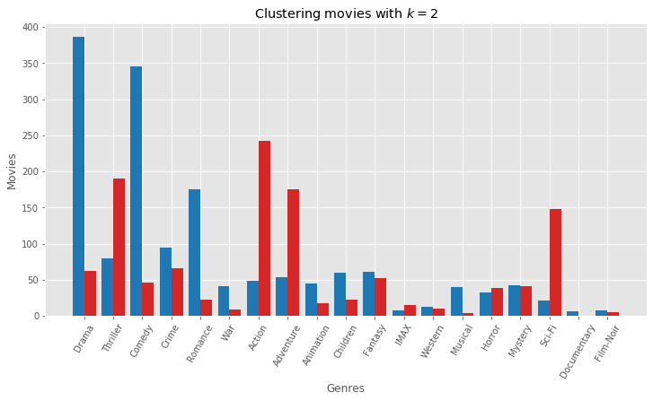

```python
width=0.4
plt.figure(figsize=(12,6))
plt.xticks(rotation=60)
plt.bar(np.arange(len(genres))-width/2,[frequencies[0].get(g,0) for g in genres],color='tab:blue',width=width)
plt.bar(np.arange(len(genres))+width/2,[frequencies[1].get(g,0) for g in genres],color='tab:red',width=width)
plt.title('Clustering movies with $k=2$')
plt.xticks(np.arange(len(genres)), genres)
plt.xlabel('Genres'); plt.ylabel('Movies')
print()
```

We can conclude that both clusters are so different. One has more drama, comedy and romance movies, while the other cluster contains more thriller, action and Sci-Fi movies.